# What do fictional characters do with machine vision in games, novels and movies?

Network analysis based on data from the Machine Vision database

Jill Walker Rettberg

# Loading the network

The network is generated from merging the characters.csv file, which describes each of the characters in the database, with `situations.csv`, which describes each “machine vision situation” we identified in the 500 creative works (novels, movies, videogames and artworks). We are only using the information about what characters do with machine vision technologies, and leave the other information (what is the technology doing, what are entities like governments or law enforcement doing) alone.

This gives us a dataframe we’ll call Character_verbs with a list of each character, their traits (gender, species, race, age and sexuality), and verbs describing the actions they take when interacting with machine vision. The verbs are either active (-ing verbs) or passive (-ed verbs) so we’ll add a TRUE/FALSE column called VerbActive.

```r
library(tidyverse)
library(RColorBrewer)
library(igraph)
library(multiplex)
library(ggraph)
library(graphlayouts)


#Import characters file (../data/Characters.csv)
#define column types and factors
AllCharacters <- read_csv(
  "../data/characters.csv",
  col_types = cols(
    CharacterID = col_integer(),
    Character = col_character(),
    Species = col_factor(levels = c(
      "Animal", "Cyborg", "Fictional",
      "Human", "Machine", "Unknown")),
    Gender = col_factor(levels = c(
      "Female","Male","Non-binary or Other", "Trans Woman",
      "Unknown")),
    RaceOrEthnicity = col_factor(levels = c(
      "Asian", "Black", "White", "Person of Colour", "Immigrant", "Indigenous",
      "Complex", "Unknown")),
    Age = col_factor(levels = c(
      "Child", "Young Adult", "Adult", "Elderly",
      "Unknown")),
    Sexuality = col_factor(levels = c(
      "Homosexual", "Heterosexual", "Bi-sexual", "Other",
      "Unknown")),
    IsGroup = col_logical(),
    IsCustomizable = col_logical()
  )
)

# Define Characters as the subset of AllCharacters that are not group characters or
# customizable characters.
#
# Convert "Unknown" values to NA.
#
# Simplify Species to just three species: human, machine or other (or NA)
#
# Simplify RaceOrEthnicity to just two options, White, PoC - or NA.
#
# NB: There are potential issues about simplifying race/ethnicity like this,
# but given how messy our original categories are, and how few occurrances
# there are of some, this seems the tidiest solution. The most problematic aspect
# is that it merges Asian characters in with other PoC, but actually many
# (most?) of the Asian characters are in works set in Asia so they are not
# minority characters. Will write more about ethical aspects of trying to
# count race at all elsewhere - note that this is a characteristic of the
# REPRESENTATION of race/ethnicity, not "real" categories or descriptions of
# real people. Use with caution.
#
# Select relevant columns.

Characters <- AllCharacters %>%
        filter(IsGroup == FALSE & IsCustomizable == FALSE) %>%
        na_if("Unknown") %>%
        mutate(Species = recode(Species,
                               "Machine" = "Robot",
                               "Cyborg" = "Robot",
                               "Human" = "Human",
                               .default = "Other")) %>%
        mutate(Race = recode(RaceOrEthnicity,
                             "Asian" = "PoC",
                             "Black" = "PoC",
                             "White" = "White",
                             "Person of Colour" = "PoC",
                             "Indigenous" = "PoC",
                             "Immigrant" = "PoC",
                             "Complex"  = "PoC")) %>%
        select(Character, Species, Gender, Sexuality,
               Race, Age)

# To figure out what these characters actually do with the machine vision we need
# to load data about the Situations in which they interact with machine vision
# technologies in the creative works in our sample.
#
# The following code imports data about the Situations from situations.csv,
# sets the column types, and also tells R to skip the columns we’re not going
# to need for this analysis.

# NB characterID isn't in this export, fix later (add column back in)
# Also remove GenreID later

Situations <- read_csv(
  "../data/situations.csv",
  col_types = cols(
    SituationID = col_integer(),
    Situation = col_skip(),
    Genre = col_character(),
    GenreID = col_skip(),
    Character = col_character(),
    Entity = col_skip(),
    Technology = col_skip(),
    Verb = col_character()
  )
)

# Filter just the three main genres - since narratives have subgenres (Movie,
# Novel, etc) there would be a lot of duplicate info if we kept them.

# The fifth row has an NA in the Character and CharacterID columns - that
# means that there is no value there. The verb in the verb column belongs
# to an Entity or a Technology, not to a Character. We need to delete all the
# rows with missing data.

Situations <- drop_na(Situations, Character) # replace w/CharID later

# Now we combine the two dataframes using the CharacterID (for now: Character)
# column as the shared information.
Character_verbs <- merge(
        x = Situations, y = Characters,
        by = "Character") %>%
                        # replace w/CharID later
        select(Character, SituationID, Genre, Verb, Species, Gender,
                Race, Age, Sexuality)

nodes_and_edges <- Character_verbs %>%
        add_count(Verb, name = "VerbCount") %>%
        arrange(desc(VerbCount)) %>%
        filter(VerbCount>20) %>%     #remove verbs that aren't used much
        mutate(VerbActive = (str_detect(Verb, "ing")))

# the mutate() creates a new col TRUE if -ing verb

# TODO: Add in Genre again when we have a new Situations export without duplicate genres for U.

nodes_chars <- nodes_and_edges %>%
        select(Title = Character, Species, Gender, Race, Age, Sexuality) %>%
        add_column(NodeType = "Character",
                   VerbCount = NA,
                   VerbActive = NA) %>%
        select(Title, NodeType, Species, Gender, Race, Age, Sexuality, VerbCount, VerbActive) %>%
        distinct()

nodes_verbs <- nodes_and_edges %>%
        select(Title = Verb, VerbActive, VerbCount) %>%
        add_column(NodeType = "Verb",
                   Species = NA,
                   Gender = NA,
                   Race = NA,
                   Age = NA,
                   Sexuality = NA) %>%
        select(Title, NodeType, Species, Gender,
               Race, Age, Sexuality, VerbCount, VerbActive) %>%
        distinct()

nodes <- rbind(nodes_chars, nodes_verbs)

edges <- nodes_and_edges %>%
        select(From = Character, To = Verb) %>%
        add_column(EdgeType = "Character_action")

# set the seed, create a graph object from the dataframe object
set.seed(123)

net <- graph_from_data_frame(d=edges, vertices=nodes, directed=T)
```

This is a bipartite network - there are two types of nodes, Characters and Verbs. We’ll add a column called “type” that will be TRUE for one kind of node and FALSE for the other kind.

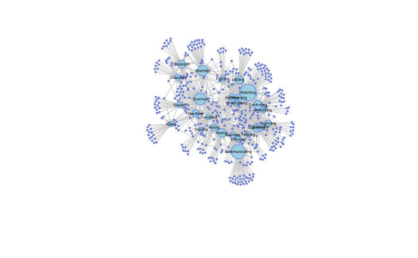

```r
## Add the "type" attribute to the network.
V(net)$type <- bipartite_mapping(net)$type

V(net)$color <- ifelse(V(net)$type, "lightblue", "salmon")
E(net)$color <- "lightgray"

# Compute node degrees (#links) and use that to set node size:
deg <- degree(net, mode="in")
V(net)$size <- deg*0.3       # the number you multiply deg by changes size of nodes

# Verbs outlets will have name labels, characters will not:
# This takes the node Titles from the nodes dataframe, but only for those
# where the NodeType is "Verb". So now only the Verbs have labels.
V(net)$label <- ""
V(net)$label[V(net)$NodeType == "Verb"] <- nodes$Title[V(net)$NodeType == "Verb"]

plot(net,
     layout=layout_with_fr(net),
     edge.arrow.size = 0.2,
     vertex.label.cex=0.4,
     vertex.label.color="black",
     vertex.label.family="Helvetica",
     label.dist = 1,
     vertex.frame.color="cornflowerblue",
     vertex.size=(V(net)$size))
```

Seeing whether different charges with the graphopt layout help.

```r
par(mfrow=c(2,2), mar=c(0,0,0,0)) # plot four figures - 2 rows, 2 columns

plot(net,
     layout=layout_with_graphopt(net, charge=0.02),
     edge.arrow.size = 0.2,
     vertex.label.cex=0.4,
     vertex.label.color="black",
     vertex.label.family="Helvetica",
     vertex.frame.color="cornflowerblue",
     vertex.size=(V(net)$size))

plot(net,
     layout=layout_with_graphopt(net, charge=0.0002),
     edge.arrow.size = 0.2,
     vertex.label.cex=0.4,
     vertex.label.color="black",
     vertex.label.family="Helvetica",
     vertex.frame.color="cornflowerblue",
     vertex.size=(V(net)$size))
```

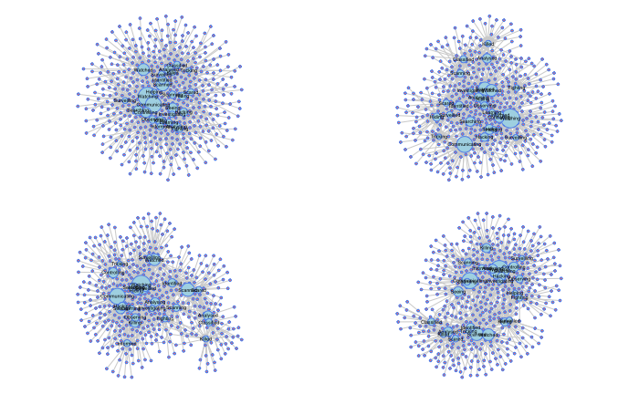

```r
plot(net,
     layout=layout_with_graphopt(net, charge=0.000002),
     edge.arrow.size = 0.1,
     vertex.label.cex=0.4,
     vertex.label.color="black",
     vertex.label.family="Helvetica",
     vertex.frame.color="cornflowerblue",
     vertex.size=(V(net)$size))

plot(net,
     layout=layout_with_graphopt(net, charge=0.0000002),
     edge.arrow.size = 0.1,
     vertex.label.cex=0.4,
     vertex.label.color="black",
     vertex.label.family="Helvetica",
     vertex.frame.color="cornflowerblue",
     vertex.size=(V(net)$size))
```

The following one seems the most legible - though really none of them are very easy to read.

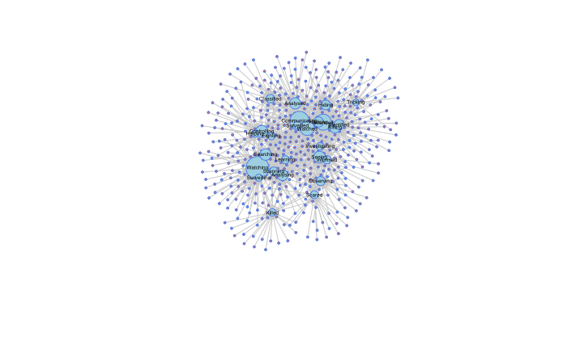

```r
plot(net,
     layout=layout_with_graphopt(net, charge=0.0002),
     edge.arrow.size = 0.2,
     vertex.label.cex=0.4,
     vertex.label.color="black",
     vertex.label.family="Helvetica",
     vertex.frame.color="cornflowerblue",
     vertex.size=(V(net)$size))
```

# Using ggraph instead of plain igraph to visualise the network

This is honestly much easier - and I like that you don’t hardcode sizes and colours into the network itself. That easily gets confusing when you re-plot and don’t realise that you’re using old values.

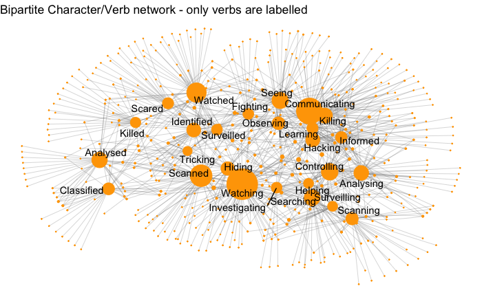

Tried to size the labels by degree as well by adding `size=V(net)$size`to the `geom_node_text()` layer but then it *only* shows Killing and a couple other verbs - no idea why it hides the other verbs.

## Try faceting by different character traits

This doesn’t really work yet - I wonder how to do it? See https://ggraph.data-imaginist.com

Maybe I need to add the attributs to the edges rather than the nodes?

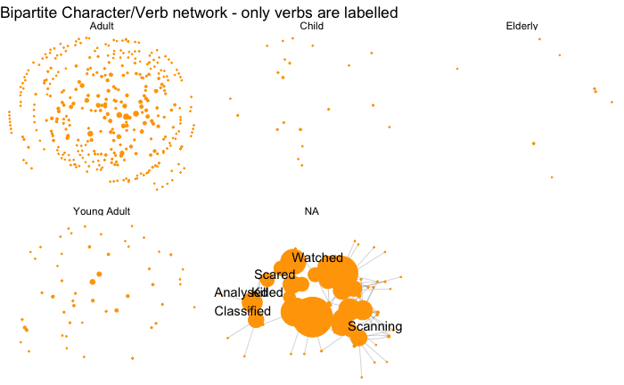

```r
ggraph(net, layout="stress") +
        geom_edge_fan(color="gray50", width=0.2, alpha=0.5) +
        geom_node_point(color="orange", size=degree(net)*0.2) +
        ggtitle("Bipartite Character/Verb network - only verbs are labelled") +
        geom_node_text(aes(label = label), color="black", repel = T) +
        theme_void() +
        facet_nodes(~Age)
```

# Convert to a one-mode network showing

For the community clustering to make much sense, we need to convert the network into a one-mode network. I want to see which verbs are used by the same characters, so I want to keep the Verbs and make an edge between two verbs if they are used by the same chaacter.

I’m following Phil Murphy and Brendan Knapp’s instructions from [Bipartite/Two-Mode Networks in igraph](https://rpubs.com/pjmurphy/317838).

There are a number of different ways of calculating this. I’m choosing the way Murphy and Knapp call “the simplest, and most common” approach, “overlap count through manual projection”, which is “a count of the number of nodes in the second mode that each pair in the first mode have in common, and visa versa”.

First we convert the network `net`to a matrix where the Verbs are columns and the Characters are rows. The “type” is set to TRUE for Verbs and FALSE for Verbs so assume switching those values would switch the columns/rows in the incidence matrix.

```r
bipartite_matrix <- as_incidence_matrix(net)
head(bipartite_matrix)
```

```
               Watching Communicating Scanned Watched Controlling Seeing Searching Analysed
"Alan Walker"         1             0       0       0           0      0         0        0
"Jake Wells"          1             0       0       1           1      0         0        0
Agent Smith           1             0       0       0           0      0         0        0
Alex (U)              1             0       0       0           0      1         0        0
Aline                 1             0       0       0           0      0         1        0
Amber Rose 348        2             1       0       0           1      2         0        0
               Killing Analysing Hacking Identified Hiding Observing Scanning Classified Informed
"Alan Walker"        0         0       0          0      0         0        0          0        0
"Jake Wells"         0         0       0          0      0         0        0          0        0
Agent Smith          1         0       0          0      0         0        0          0        0
Alex (U)             0         0       0          0      0         1        0          0        0
Aline                0         0       0          0      0         0        0          0        0
Amber Rose 348       0         0       0          0      0         0        0          0        0
               Learning Scared Fighting Surveilled Investigating Killed Surveilling Helping
"Alan Walker"         0      0        0          0             0      0           1       0
"Jake Wells"          0      0        0          0             0      0           0       0
Agent Smith           0      0        0          0             0      0           0       0
Alex (U)              0      0        0          0             0      0           0       0
Aline                 0      0        0          0             0      0           0       0
Amber Rose 348        0      0        0          0             0      0           0       0
               Tricking
"Alan Walker"         0
"Jake Wells"          0
Agent Smith           0
Alex (U)              0
Aline                 0
Amber Rose 348        0
```

You can transpose (swap) rows and columns using `(t(bipartite_matrix))`.

You convert this bipartite matrix to a one-mode matrix by multiplying it by its transpose. This is really well explained in Murphy and Knapp.

Paraphrasing them:

To produce a Y by Y (Character x Character) network, multiply the matrix we have above by its transpose (AA’). To produce an X by X network (Verb x Verb), multiply the transposed network by the original (A’A). So, let’s try it.

This code produces a network of how characters are related to each other - two characters have an edge between them if they use the same verb. This could be useful for seeing whether characters that “cluster together” based on their actions when interacting with machine vision also have other traits in common, such as gender, race, species or age.

```r
character_matrix_prod <- bipartite_matrix %*% t(bipartite_matrix)
## crossprod() does same and scales better, but this is better to learn at first at first so you understand the method
##
# diag() removes any self-loops - sets all the diagonals to 0
# so for you don't get watching has 86 edges to watching etc.
diag(character_matrix_prod) <- 0
```

The next code does the opposite, and produces a network of how verbs are related to each other. Two verbs have an edge between them if they are used by the same character. Do certain kinds of verb cluster together?

It could be interesting to see if there are differences over time or between genres (games vs movies vs novels, for instance). I will have to add dates and genres to the network for this to work.

```r
verb_matrix_prod <- t(bipartite_matrix) %*% bipartite_matrix
diag(verb_matrix_prod) <- 0
```

## One-mode verb-verb network

I’ll start by making the one-mode verb-verb network.

```r
verb_net <- graph_from_adjacency_matrix(verb_matrix_prod,
                                        mode = "undirected",
                                        weighted = TRUE)

verb_net
```

```
IGRAPH 3cba348 UNW- 26 233 --
+ attr: name (v/c), weight (e/n)
+ edges from 3cba348 (vertex names):
 [1] Watching--Communicating Watching--Scanned       Watching--Watched
 [4] Watching--Controlling   Watching--Seeing        Watching--Searching
 [7] Watching--Analysed      Watching--Killing       Watching--Analysing
[10] Watching--Hacking       Watching--Identified    Watching--Hiding
[13] Watching--Observing     Watching--Scanning      Watching--Classified
[16] Watching--Informed      Watching--Learning      Watching--Scared
[19] Watching--Fighting      Watching--Surveilled    Watching--Investigating
[22] Watching--Killed        Watching--Surveilling   Watching--Helping
+ ... omitted several edges
```

`verb_net` is now a network ready to be plotted. The four character code says it’s Undirected, Named and Weighted. Each edge has an attribute called `weight`that is the number of times that connection occured - so how many times a character used both verbs. Watching and Communicating have the weight 11, so a character both watched and communicated when interacting with machine vision 11 times.

TODO: If doing this with Technologies and Verbs it will be important to somehow include information about the situation somehow when weighting.

This is a much smaller network and easier to visualise. I’m going to try doing this in ggraph which is closer to ggplot.

## Clustering the Verbs - two methods

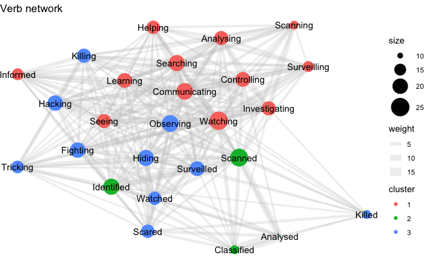

```r
# define a custom color palette
got_palette <- c("#1A5878", "#C44237", "#AD8941")

# compute a clustering for node colors
V(verb_net)$cluster <- as.character(membership(cluster_louvain(verb_net)))

# compute degree as node size
V(verb_net)$size <- degree(verb_net)

ggraph(verb_net, layout="fr") +
        #geom_edge_fan(color="gray50", width=0.2, alpha=0.5) +
        geom_edge_link0(aes(edge_width = weight), edge_colour = "grey80", alpha=0.3)+
        geom_node_point(aes(color = cluster, size = size)) +
        geom_node_text(aes(label = name), size=4, color="black", repel=F, check_overlap = T) +
        scale_fill_manual(values = got_palette) +
        scale_size(range = c(0.2,10)) +
        ggtitle("Verb network") +
        theme_void()
```

```r
NA
NA
```

Ognayanova has another way of showing communities:

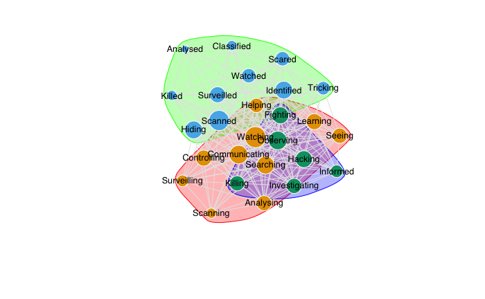

```r
# From Sunbelt2019.
# We can also try to make the network map more useful by
# showing the communities within it.

# Community detection (by optimizing modularity over partitions):
clp <- cluster_optimal(verb_net)
l <- layout_with_graphopt(verb_net, charge=0.002)

# Community detection returns an object of class "communities"
# which igraph knows how to plot:

plot(clp, verb_net,
     layout=l,
     label.dist = 1,
     edge.color = "grey90",
     edge.arrow.size = 0.2,
     vertex.frame.color=F,
     vertex.label.cex=0.8,
     vertex.label.color="black",
     vertex.label.family="Helvetica")
```

```r
NA
```

It’s interesting seeing the clusters of verbs. Hacking, fighting, killing seem to go well together, but informed and investigating? Learning, seeing, watching, communnicating, helping, surveilling, searching, analysing, scanning - these clearly go together.

An interesting next step would be to investigate the traits of characters using each of these sets of verbs. That might be best done in a set of barcharts rather than using network visualistion.

TODO: - Figure out how to get the cluster numbers and add that to the `Character_verbs` dataframe. - Figure out how to make this graph prettier and add a legend

This uses a different cluster algorithm than the one I found in David Schoch’s Network Visualizations in R using ggraph and graphlayouts](http://mr.schochastics.net/netVizR.html), which looked like this: `V(verb_net)$cluster <- as.character(membership(cluster_louvain(verb_net)))`  
Schach added the cluster ID (1, 2 or 3) to an attribute in `verb_net` whereas Ognayanova put them in a separate vector that can be passed to plot.

I think the `cluster_optimal` clusters are more interesting than the louvain version. Let’s try to use `cluster_optimal` with the ggraph version of the network.

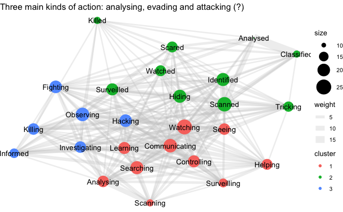

```r
# compute a clustering for node colors
V(verb_net)$cluster <- as.character(membership(cluster_optimal(verb_net)))

ggraph(verb_net, layout="fr") +
        #geom_edge_fan(color="gray50", width=0.2, alpha=0.5) +
        geom_edge_link0(aes(edge_width = weight), edge_colour = "grey80", alpha=0.3)+
        geom_node_point(aes(color = cluster, size = size)) +
        geom_node_text(aes(label = name), size=4, color="black", repel=F, check_overlap = T) +
        scale_fill_manual(values = got_palette) +
        scale_size(range = c(0.2,10)) +
        ggtitle("Three main kinds of action: analysing, evading and attacking (?)") +
        theme_void()
```

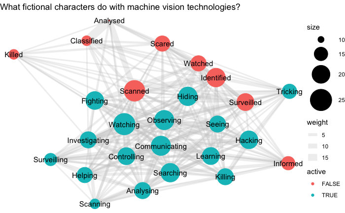

```r
# Make a new attribute to the nodes - active or passive. Active verbs will be TRUE.
V(verb_net)$active <- str_detect(V(verb_net)$name, "ing")

ggraph(verb_net, layout="fr") +
        #geom_edge_fan(color="gray50", width=0.2, alpha=0.5) +
        geom_edge_link0(aes(edge_width = weight), edge_colour = "grey80", alpha=0.3)+
        geom_node_point(aes(color = active, size = size)) +
        geom_node_text(aes(label = name), size=4, color="black", repel=F, check_overlap = T) +
        scale_fill_manual(values = got_palette) +
        scale_size(range = c(0.5,15)) +
        ggtitle("What fictional characters do with machine vision technologies?") +
        theme_void()
```

This graph is drawn slightly differently every time. I’m not sure how to save a layout as shown in Sunbelt 2019 on page 23 (`l <- layout_with_fr(net)` and then setting ´layout = l´ later - can you do that in ggraph?)

Here’s a layout that emphasises centrality - and hey presto, that sizes labels!! THis code is from [David Schoch](http://mr.schochastics.net/netVizR.html) again.

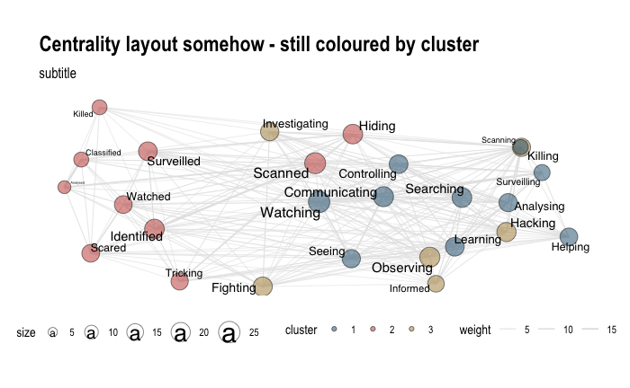

Does this mean that Scanned is very central? Who knows. It’s time to run the numbers.

## Degree

### The five nodes with highest degree

```r
head(net_degree_sorted)
```

```
     Watching       Scanned Communicating     Observing     Searching    Identified
           25            24            22            22            21            21
```

### Histogram of degrees

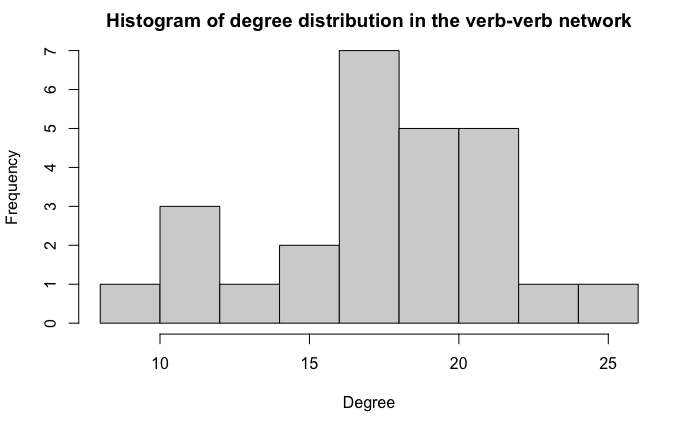

### Five highest betweenness centrality

```r
head(sort(verb_net_btwn, decreasing = T))
```

```
    Killed     Hiding   Fighting Surveilled Identified   Tricking
  35.34524   29.64524   28.21905   19.32976   18.77857   17.58214
```

### Five highest Eigenvector centrality

```r
head(sort(eigenCent, decreasing = TRUE))
```

```
     Watching Communicating   Controlling     Searching        Seeing       Scanned
    1.0000000     0.9110513     0.7695477     0.6809335     0.6525046     0.6483450
```

### Correlation between betweenness centrality and eigenvector centrality

```r
 cor(verb_net_btwn,eigenCent)
```

```
[1] -0.4987839
```

Nodes with high betweenness but low eigencentrality are supposed to be “gatekeeper vertices” between disparate communities. We can colour them red like this:

```r
plot(verb_net,
     layout=l,
     label.dist = 1,
     edge.color = "grey90",
     edge.arrow.size = 0.2,
     vertex.color = color,
     vertex.frame.color=F,
     vertex.label.cex=0.8,
     vertex.label.color="black",
     vertex.label.family="Helvetica")
```

[output not shown]

I’m not sure how this matches the other clustering we’ve done. If we use the ggraph for a fr layout, but put `fill = color`in `geom_node_point` I would expect the colouring of nodes to be as above in the igraph `plot()` - but weirdly the colours are inverted.

I really don’t see how these are “gatekeeper vertices”. Perhaps not in this particular network?

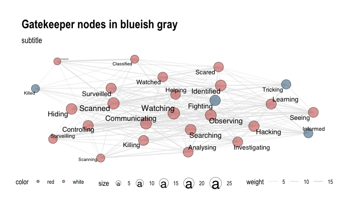

### A subset centered on a single node

Can’t figure this out - does lesmis$S and lesmis$R exist? Go through the lesmis tutorial again to figure this out.

```r
#To create a larger subgraph for all connections in both directions, use this instead:
#lesmis_subset_nodes <- c(lesmis$S[lesmis_subset_rownumbers], lesmis$R[lesmis_subset_rownumbers])
verb_net_subset_nodes
```

```r
plot(verb_net_subgraph, edge.arrow.size = 0.2,
     vertex.size=5, vertex.label.cex=0.5,
     vertex.color="white", vertex.frame.color="light gray",
     main=paste("All characters connected to", targetverbs, sep=" ") )
```

[output not shown]

# Notes and TODOs

## Findings and notes

- Some interesting findings from the three clusters of nodes - evading, analysing and attacking as main categories. Seems very clear.

## TODO

- Get a new export of situations.csv and include genres - run these for each genre (art, narrative, games) to compare.
- Run the same kind of analysis as I did for verb_net on the one-mode character-character network.
- Figure out how to add character attributes to the network - especially genre. Does it make sense to add these to the edges? Is that even possible? How to do faceting (`facet_nodes()` etc)
- Add the community ID data to Character_verbs and make some barcharts to see whether the three action groups correlate with particular Character traits (species, gender, race etc)